# MSDS 6306 - Live Session Unit 03 Assignment

Dmitry Andreev

January 31, 2018

## Question 1 - GitHub Cloning

This question asks us to use Git to to clone the following repository to a local directory on our computer: https://github.com/caesar0301/awesome-public-datasets

I used Windows PowerShell to complete this requirement as follows:  
(Note: below each listed step, I have included the input command that I used in PowerShell)

1. Check current directory

```bash
pwd
```

```
## /cygdrive/c/Users/Dmitr/Desktop/MSDS 6306 - 402/Unit 3/Homework
```

2. Navigate to MSDS 6306 Homework 3 folder

```bash
cd "C:\Users\Dmitr\Desktop\MSDS 6306 - 402\Unit 3\Homework"
```

3. Making a new folder / local repository called HW3GitRepo

```bash
mkdir HW3GitRepo
```

4. Navigate into newly created HW3GitRepo local repository

```bash
cd "C:\Users\Dmitr\Desktop\MSDS 6306 - 402\Unit 3\Homework\HW3GitRepo"
```

5. Initial setup of a repository in the newly created HW3GitRepo folder

```bash
git init "C:\Users\Dmitr\Desktop\MSDS 6306 - 402\Unit 3\Homework\HW3GitRepo"
```

```
## Initialized empty Git repository in C:/Users/Dmitr/Desktop/MSDS 6306 - 402/Unit 3/Homework/HW3GitRepo/.git/
```

6. Clone GitHub repository from URL given in question statement

```bash
git clone https://github.com/caesar0301/awesome-public-datasets
```

```
## Cloning into 'awesome-public-datasets'...
```

## Question 2 - Data Summary

For this question we are asked to extract the titanic.csv file from the zip compressed file included in the cloned repo from question 1 above and complete the following steps:

1. Read in dataset contained in the titanic.csv extracted file and assign it to df.

```r
df <- read.csv("C:/Users/Dmitr/Desktop/MSDS 6306 - 402/Unit 3/Homework/awesome-public-datasets2/Datasets/titanic.csv/titanic.csv", stringsAsFactors = TRUE)
```

2. Output the respective count of females and males aboard the Titanic. Plot the frequency of females and males.

```r
summary(df$Sex)
```

```
## female   male
##    314    577
```

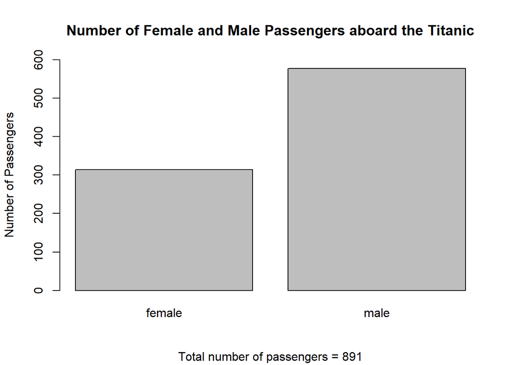

```r
plot(df$Sex,
     ylim = c(0, 600),
     ylab = "Number of Passengers",
     main = "Number of Female and Male Passengers aboard the Titanic",
     sub = "Total number of passengers = 891")
```

3. Use one apply function to output the means of Age, Fare, and Survival.

```r
sapply(df[c("Age", "Fare", "Survived")], mean, na.rm = TRUE)
```

```
##        Age       Fare   Survived
## 29.6991176 32.2042080  0.3838384
```

## Question 3 - Function Building

For this question we are asked to create a helper function that can analyze a sleep research data set downloaded from http://talklab.psy.gla.ac.uk/L1_labs/lab_1/homework/index.html and are given a list of instructions that this function should execute.

```r
SleepData <- read.csv("http://talklab.psy.gla.ac.uk/L1_labs/lab_1/homework/sleep_data_01.csv")

SleepFunction <- function(x = SleepData) {
  median_age <- median(x$Age, na.rm = TRUE)
  min_sleep <- min(x$Duration, na.rm = TRUE)
  max_sleep <- max(x$Duration, na.rm = TRUE)
  mean_RSES <- mean(x$RSES, na.rm = TRUE)
  sd_RSES <- sd(x$RSES, na.rm = TRUE)
  report <- data.frame(median_age, mean_RSES / 5, sd_RSES / 5, c(max_sleep - min_sleep))
  colnames(report) <- c("MedianAge", "SelfEsteem", "SE_SD", "DurationRange")
  round(report, 1)
}

SleepFunction(SleepData)
```

```
##   MedianAge SelfEsteem SE_SD DurationRange
## 1        14        3.6   1.2             7
```